# roc_musiteDeep

```python
from sys import path
base_path = "/media/paulati/Nuevo vol/paula/ingebi/2020/agustina_mazzella/github/arabidopsis_phospho"
path.append(base_path)

from preparation import util
```

```python
from os import path, remove
import pandas as pd
import numpy as np
import matplotlib.pyplot as plt
import statistics as stats
from sklearn import metrics
from sklearn.metrics import roc_curve, roc_auc_score, auc, precision_recall_curve, f1_score, confusion_matrix, recall_score, precision_score
```

```python
musite_results_base_path = path.join(base_path, 'data/results/musitedeep')
musiteDeep_prediction_score_by_id_base_file_path = path.join(musite_results_base_path, "Prediction_results_score_by_id_base.txt")
```

```python
musite_scores_file_path = musiteDeep_prediction_score_by_id_base_file_path.replace(".txt", ".zip")
musite_scores_data = pd.read_csv(musite_scores_file_path, sep = "\t")
musite_scores_data
```

|  | protein_id_base | min_score | max_score | mean_score |
| --- | --- | --- | --- | --- |
| 0 | AT1G01010 | 0.788 | 0.788 | 0.788000 |
| 1 | AT1G01020 | 0.263 | 0.741 | 0.661333 |
| 2 | AT1G01030 | 0.836 | 0.836 | 0.836000 |
| 3 | AT1G01040 | 0.882 | 0.882 | 0.882000 |
| 4 | AT1G01050 | 0.786 | 0.786 | 0.786000 |
| ... | ... | ... | ... | ... |
| 27643 | ATMG01330 | 0.875 | 0.875 | 0.875000 |
| 27644 | ATMG01350 | 0.695 | 0.695 | 0.695000 |
| 27645 | ATMG01360 | 0.438 | 0.438 | 0.438000 |
| 27646 | ATMG01370 | 0.624 | 0.624 | 0.624000 |
| 27647 | ATMG01400 | 0.912 | 0.912 | 0.912000 |

27648 rows × 4 columns

```python
experimental_file_path = path.join(base_path, "data/preproc/experimental_ids.zip")
experimental_data = pd.read_csv(experimental_file_path, sep = "\t")
```

```python
musite_scores_data.index = musite_scores_data.protein_id_base
experimental_data.index = experimental_data.code
musite_experimental_data = musite_scores_data.join(experimental_data, how = "outer")
#musite_experimental_data
```

```python
musite_experimental_data["label"] = [1 if x is not np.NaN else 0 for x in musite_experimental_data.code.values]
musite_experimental_data["color"] = ["orange" if x == 1 else "blue" for x in musite_experimental_data.label.values]
```

```python
musite_experimental_data
```

|  | protein_id_base | min_score | max_score | mean_score | code | label | color |
| --- | --- | --- | --- | --- | --- | --- | --- |
| AT1G01010 | AT1G01010 | 0.788 | 0.788 | 0.788000 | NaN | 0 | blue |
| AT1G01020 | AT1G01020 | 0.263 | 0.741 | 0.661333 | NaN | 0 | blue |
| AT1G01030 | AT1G01030 | 0.836 | 0.836 | 0.836000 | AT1G01030 | 1 | orange |
| AT1G01040 | AT1G01040 | 0.882 | 0.882 | 0.882000 | AT1G01040 | 1 | orange |
| AT1G01050 | AT1G01050 | 0.786 | 0.786 | 0.786000 | AT1G01050 | 1 | orange |
| ... | ... | ... | ... | ... | ... | ... | ... |
| ATMG01330 | ATMG01330 | 0.875 | 0.875 | 0.875000 | NaN | 0 | blue |
| ATMG01350 | ATMG01350 | 0.695 | 0.695 | 0.695000 | NaN | 0 | blue |
| ATMG01360 | ATMG01360 | 0.438 | 0.438 | 0.438000 | NaN | 0 | blue |
| ATMG01370 | ATMG01370 | 0.624 | 0.624 | 0.624000 | NaN | 0 | blue |
| ATMG01400 | ATMG01400 | 0.912 | 0.912 | 0.912000 | NaN | 0 | blue |

27648 rows × 7 columns

```python
import seaborn as sns
```

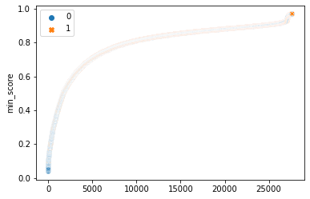

```python
musite_experimental_data_sort = musite_experimental_data.sort_values(by="min_score", ascending= True)
sns.scatterplot(x = range(musite_experimental_data_sort.shape[0]), y = musite_experimental_data_sort.min_score,
                hue = musite_experimental_data_sort.label.values, style = musite_experimental_data_sort.label.values)
```

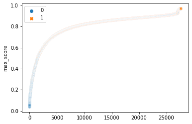

```python
musite_experimental_data_sort = musite_experimental_data.sort_values(by="max_score", ascending= True)
sns.scatterplot(x = range(musite_experimental_data_sort.shape[0]), y = musite_experimental_data_sort.max_score,
                hue = musite_experimental_data_sort.label.values, style = musite_experimental_data_sort.label.values)
```

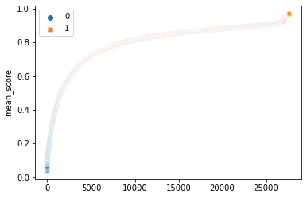

```python
musite_experimental_data_sort = musite_experimental_data.sort_values(by="mean_score", ascending= True)
sns.scatterplot(x = range(musite_experimental_data_sort.shape[0]), y = musite_experimental_data_sort.mean_score,
                hue = musite_experimental_data_sort.label.values, style = musite_experimental_data_sort.label.values)
```

```python
musite_experimental_data.label.value_counts()
```

```
0    14511
1    13137
Name: label, dtype: int64
```

```python
y = musite_experimental_data.label

probs = musite_experimental_data.max_score

fpr, tpr, thresholds = roc_curve(y, probs)

auc = roc_auc_score(y, probs)
```

```python
auc
```

```
0.7304366073038685
```

## ROC Curve

```python
# generate a no skill prediction (majority class)
ns_probs = [0 for _ in range(musite_experimental_data.shape[0])]
# keep probabilities for the positive outcome only
musite_probs = musite_experimental_data.max_score
```

```
No Skill: ROC AUC=0.500
Logistic: ROC AUC=0.730
```

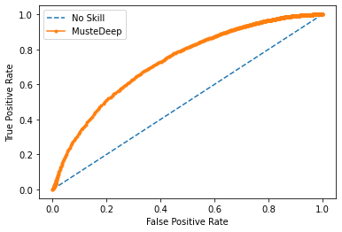

```python
# calculate scores
ns_auc = roc_auc_score(musite_experimental_data.label, ns_probs)
musite_auc = roc_auc_score(musite_experimental_data.label, musite_probs)
# summarize scores
print('No Skill: ROC AUC=%.3f' % (ns_auc))
print('Logistic: ROC AUC=%.3f' % (musite_auc))
# calculate roc curves
ns_fpr, ns_tpr, _ = roc_curve(musite_experimental_data.label, ns_probs)
musite_fpr, musite_tpr, _ = roc_curve(musite_experimental_data.label, musite_probs)
# plot the roc curve for the model
plt.plot(ns_fpr, ns_tpr, linestyle='--', label='No Skill')
plt.plot(musite_fpr, musite_tpr, marker='.', label='MusteDeep')
# axis labels
plt.xlabel('False Positive Rate')
plt.ylabel('True Positive Rate')
# show the legend
plt.legend()
# show the plot
plt.show()
```

## Optimal threshold

1.

This code evaluates `thresholds_count` samples looking for optimal threshold.

`data_frac` specify the proportion of the dataset records evaluated in each sample.

Optimal threshold as the maximum `abs(tpr-fpr)`

```python
def calculate_j_score(tpr, fpr, score_type):
    if score_type == 1:
        j_scores = abs(tpr-fpr)
    elif score_type == 2:
        #j_scores = np.sqrt(((1-tpr) * (1-tpr)) + (fpr * fpr))
        j_scores = np.sqrt(((1-tpr) * (1-tpr)) + (fpr * fpr))
        j_scores = -j_scores
    return j_scores



def calculate_optimal_thresholds(pred_exp_data, thresholds_count, data_frac, score_type=1):

    result = []

    exp_pos_mask = pred_exp_data.label == 1
    exp_pos = pred_exp_data.loc[exp_pos_mask, :]
    prop_exp_pos = exp_pos_mask.sum() / pred_exp_data.shape[0]

    exp_neg_mask = pred_exp_data.label == 0
    exp_neg = pred_exp_data.loc[exp_neg_mask, :]
    prop_exp_neg = exp_neg_mask.sum() / pred_exp_data.shape[0]

    pos_sample_count = round(data_frac * prop_exp_pos * pred_exp_data.shape[0])
    print(pos_sample_count)

    neg_sample_count = round(data_frac * prop_exp_neg * pred_exp_data.shape[0])
    print(neg_sample_count)

    for i in range(thresholds_count):

        sample_pos = exp_pos.sample(pos_sample_count, replace = True, axis = 0 )

        #print(sample_pos.shape[0])

        sample_neg = exp_neg.sample(neg_sample_count, replace = True, axis = 0 )

        #print(sample_neg.shape[0])

        sample = pd.concat([sample_pos, sample_neg], axis = 0)

        #print(sample.shape[0])

        y = pd.Categorical(sample.label.values)

        scores = sample.max_score.values

        fpr, tpr, thresholds = roc_curve(y, scores, pos_label=1)
    #roc_auc = metrics.auc(fpr, tpr)

        #j_scores = abs(tpr-fpr)
        j_scores = calculate_j_score(tpr, fpr, score_type)

        optimal_idx = np.argmax(j_scores)

        optimal_threshold = thresholds[optimal_idx]

        result.append(optimal_threshold)


    return(result)
```

```python
optimal_thresholds = calculate_optimal_thresholds(musite_experimental_data, 5000, 0.3, 1)
print(np.mean(optimal_thresholds))
print(np.std(optimal_thresholds))
```

```
3941
4353
0.8512617999999998
0.006360319234126541
```

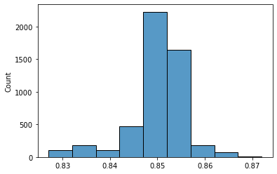

```python
sns.histplot(optimal_thresholds, binwidth = 0.005)
```

```python
optimal_1 = stats.mode(optimal_thresholds)
optimal_1
```

```
0.852
```

```python
np.mean(optimal_thresholds)
```

```
0.8512617999999998
```

Without sampling:

```python
optimal_thresholds = calculate_optimal_thresholds(musite_experimental_data, 1, 1, 1)
optimal_thresholds
```

```
13137
14511
```

```
[0.852]
```

2.

Pick the threshold t∗ that minimizes the distance to the top left can be done by measuring its distance

$distance = (0, 1) - (fpr, tpr)$

$= (-fpr, 1-tpr)$

$= \sqrt{(-fpr)^2 + (1-tpr)^2}$

$t∗ = argmin_t(\sqrt{fpr_t^2 + (1 - tpr_t)^2}$

$t∗ = argmax_t(- \sqrt{fpr_t^2 + (1 - tpr_t)^2}$

```python
optimal_thresholds = calculate_optimal_thresholds(musite_experimental_data, 5000, 0.3, 2)
print(np.mean(optimal_thresholds))
print(np.std(optimal_thresholds))
```

```
3941
4353
0.852921
0.002210058596508249
```

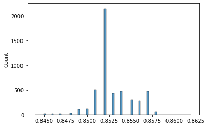

```python
sns.histplot(optimal_thresholds)
```

```python
optimal_2 = stats.mode(optimal_thresholds)
optimal_2
```

```
0.852
```

```python
optimal_thresholds = calculate_optimal_thresholds(musite_experimental_data, 1, 1, 2)
optimal_thresholds
```

```
13137
14511
```

```
[0.8540000000000001]
```

## Confusion matrix

```python
y_true = musite_experimental_data.label
```

```python
optimal_threshold_1 = optimal_1
y_pred_optimal_1 = [1 if x >= optimal_threshold_1 else 0 for x in musite_experimental_data.max_score.values]
conf_matrix = confusion_matrix(y_true, y_pred_optimal_1)
conf_matrix
```

```
array([[9591, 4920],
       [4250, 8887]])
```

```python
optimal_threshold_2 = optimal_2
y_pred_optimal_2 = [1 if x >= optimal_threshold_2 else 0 for x in musite_experimental_data.max_score.values]
confusion_matrix(y_true, y_pred_optimal_2)
```

```
array([[9591, 4920],
       [4250, 8887]])
```

```python
default_threshold = 0.5
y_pred_default = [1 if x >= default_threshold else 0 for x in musite_experimental_data.max_score.values]
confusion_matrix(y_true, y_pred_default)
```

```
array([[ 1345, 13166],
       [  103, 13034]])
```

**Threshold is set in 0.852**

```python
tn, fp, fn, tp = conf_matrix.ravel()

specificity = tn / (tn + fp)
specificity
```

```
0.6609468678933224
```

```python
sensitivity = tp /(tp + fn)
sensitivity
```

```
0.6764862601811676
```

```python
fdr = fp / (fp + tn)
fdr
```

```
0.3390531321066777
```

```python
musite_thr_recall = recall_score(y_true, y_pred_optimal_1)
print(musite_thr_recall)
musite_thr_precision = precision_score(y_true, y_pred_optimal_1)
print(musite_thr_precision)
```

```
0.6764862601811676
0.6436590135438546
```

## Precision-Recall

[figure not shown]

source: https://en.wikipedia.org/wiki/Precision_and_recall#/media/File:Precisionrecall.svg

The precision-recall curve shows the tradeoff between precision and recall for different threshold.

A high area under the curve represents both high recall and high precision, where high precision relates to a low false positive rate, and high recall relates to a low false negative rate.

High scores for both show that the classifier is returning accurate results (high precision), as well as returning a majority of all positive results (high recall).

source: https://scikit-learn.org/stable/auto_examples/model_selection/plot_precision_recall.html

```
MusiteDeep: f1=0.660 auc=0.685
```

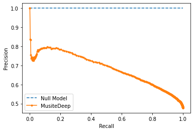

```python
musite_precision, musite_recall, _ = precision_recall_curve(musite_experimental_data.label, musite_probs)
# calculate scores

y_pred = [1 if x >= optimal_1 else 0 for x in musite_experimental_data.max_score.values]

musite_f1 = f1_score(musite_experimental_data.label, y_pred)

musite_auc = metrics.auc(musite_recall, musite_precision)
# summarize scores
print('MusiteDeep: f1=%.3f auc=%.3f' % (musite_f1, musite_auc))
# plot the precision-recall curves
no_skill = len(musite_experimental_data.label == 1) / len(musite_experimental_data.label)
plt.plot([0, 1], [no_skill, no_skill], linestyle='--', label='Null Model')
plt.plot(musite_recall, musite_precision, marker='.', label='MusiteDeep')
# axis labels
plt.xlabel('Recall')
plt.ylabel('Precision')
# show the legend
plt.legend()
# show the plot
plt.show()
```

```python
threshold_count = 100
thresholds = []
for i in range(threshold_count):
    threshold = i / threshold_count
    thresholds.append(threshold)

f1_scores = []
recall_scores = []
precision_scores = []
y_true = musite_experimental_data.label

for threshold in thresholds:
    y_pred = [1 if x >= threshold else 0 for x in musite_experimental_data.max_score.values]
    if(np.sum(y_pred) > 0):
        precision = precision_score(y_true, y_pred)
    else:
        precision = 0
    f1 = f1_score(y_true, y_pred)
    recall = recall_score(y_true, y_pred)
    f1_scores.append(f1)
    recall_scores.append(recall)
    precision_scores.append(precision)
```

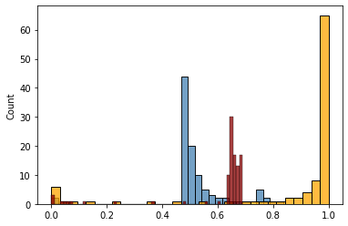

```python
sns.histplot(precision_scores, color="steelblue")
sns.histplot(recall_scores, color="orange")
sns.histplot(f1_scores, color = "darkred")
```

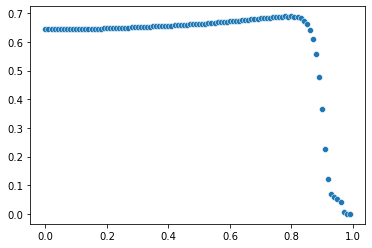

```python
sns.scatterplot(x = thresholds, y = f1_scores)
```

```python
max(f1_scores)
```

```
0.6896776294366656
```

```python
index = np.argmax(f1_scores)
print(recall_scores[index])
print(precision_scores[index])
```

```
0.88673213062343
0.5642801782600271
```

Metrics with optimal_1 threshold :

```python
y_pred = [1 if x >= optimal_1 else 0 for x in musite_experimental_data.max_score.values]

f1 = f1_score(y_true, y_pred)
recall = recall_score(y_true, y_pred)
precision = precision_score(y_true, y_pred)

print(f1)
print(recall)
print(precision)
```

```
0.6596644893111638
0.6764862601811676
0.6436590135438546
```

## How many experimental ids are not predicted as phosphorilated by musiteDeep and this threshold?

```python
y_pred_mask = musite_experimental_data.max_score.values >= optimal_1

print(y_pred_mask.sum())

y_pred = musite_experimental_data.loc[y_pred_mask, 'protein_id_base']

exp_not_predicted = [x for x in experimental_data.code.values if x not in y_pred ]

len(exp_not_predicted)
```

```
13807
```

```
4250
```

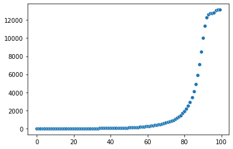

```python
thr_count = 100

exp_not_predicted_data = []

for i in range(thr_count):

    threshold = i/thr_count

    mask_exp_not_pred = np.logical_and(pd.notnull(musite_experimental_data.code), musite_experimental_data.max_score.values < threshold)

    count = mask_exp_not_pred.sum()

    exp_not_predicted_data.append(count)

sns.scatterplot(x = range(thr_count), y = exp_not_predicted_data)
```

## How many ids predicted as phosphorilated by musiteDeep and this threshold have not experimental evidence?

```python
y_pred_mask = musite_experimental_data.max_score.values >= optimal_1

y_pred = musite_experimental_data.loc[y_pred_mask, 'protein_id_base']

predicted_no_exp = [x for x in y_pred if x not in experimental_data.code.values]
len(predicted_no_exp)
```

```
4920
```

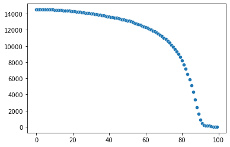

```python
thr_count = 100

predicted_no_exp_data = []

exp_data = np.unique(experimental_data.code.values)

for i in range(thr_count):

    threshold = i/thr_count

    mask_pred_not_exp = np.logical_and(pd.isnull(musite_experimental_data.code), musite_experimental_data.max_score.values >= threshold)

    count = mask_pred_not_exp.sum()

    predicted_no_exp_data.append(count)

sns.scatterplot(x = range(thr_count), y = predicted_no_exp_data)
```

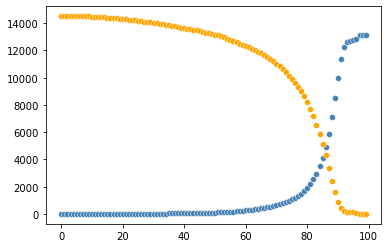

```python
sns.scatterplot(x = range(thr_count), y = exp_not_predicted_data, color = "steelblue")
sns.scatterplot(x = range(thr_count), y = predicted_no_exp_data, color = "orange")
```

## References

https://machinelearningmastery.com/roc-curves-and-precision-recall-curves-for-classification-in-python/

https://stats.stackexchange.com/questions/123124/how-to-determine-the-optimal-threshold-for-a-classifier-and-generate-roc-curve

http://www0.cs.ucl.ac.uk/staff/W.Langdon/roc/

```python
optimal_1
```

```
0.852
```